# SOS Biologiacal data visualisation: TESTOSTERONE

#load libraries: library(dplyr) library(tidyverse) library(ggplot2) library(“data.table”) library(stringr) library(“plyr”) library(ggpubr) library(DescTools) library(MESS)

```r
#import cleaned bioloigcal dataset:
setwd("~/Documents/8_Byrne_work/SOS_Bioloigical_data_cleaned")
SOS_hormones_cleaned <- read.csv('SOS_hormones_cleaned.csv')
SOS_hormones_cleaned$SampleID <- as.character(SOS_hormones_cleaned$SampleID)

#Create variable specfic to Cortisol:
SOS_Testosterone <- SOS_hormones_cleaned[,c("SampleID", "Time","Testosterone_pg_mL", "Testosterone_log", "Testosterone_nontran_win")]

#Remove participants who do not have all 3 timepoints:
SOS_Testosterone_T1 = SOS_Testosterone %>% filter(Time == "1")
SOS_Testosterone_T2 = SOS_Testosterone %>% filter(Time == "2")
SOS_Testosterone_T3 = SOS_Testosterone %>% filter(Time == "3")
SOS_Testosterone_T4 = SOS_Testosterone %>% filter(Time == "4")

Merge1 <-merge(SOS_Testosterone_T1, SOS_Testosterone_T2, by = "SampleID", all = FALSE, all.x = TRUE)
Merge2 <-merge(Merge1, SOS_Testosterone_T3, by = "SampleID", all = FALSE, all.x = TRUE)
SOS_Testosterone_reshaped <-merge(Merge2, SOS_Testosterone_T4, by = "SampleID", all = FALSE, all.x = TRUE)
```

```
column names ‘Time.x’, ‘Testosterone_pg_mL.x’, ‘Testosterone_log.x’, ‘Testosterone_nontran_win.x’, ‘Time.y’, ‘Testosterone_pg_mL.y’, ‘Testosterone_log.y’, ‘Testosterone_nontran_win.y’ are duplicated in the result
```

```r
SOS_Testosterone_all_timepoints <- na.omit(SOS_Testosterone_reshaped)

#Merge to now include only the people who have all 4 timepoints:
SOS_Testosterone_final <- merge(SOS_Testosterone, SOS_Testosterone_all_timepoints, by = "SampleID", all = FALSE)
SOS_Testosterone_final <- SOS_Testosterone_final[1:5]
colnames(SOS_Testosterone_final) <- c("SampleID", "Time","Testosterone_pg_mL", "Testosterone_log", "Testosterone_nontran_win")
SOS_Testosterone_final <- (SOS_Testosterone_final %>% arrange(SampleID,Time))

#Clear variables no longer needed:
rm(SOS_Testosterone_T1, SOS_Testosterone_T2,SOS_Testosterone_T3,SOS_Testosterone_T4, Merge1, Merge2, SOS_Testosterone_reshaped, SOS_Testosterone_all_timepoints)

total <- unique(SOS_Testosterone$SampleID)
total_keep <- unique(SOS_Testosterone_final$SampleID)
perc_all_timepoints <- ((length(total_keep))/(length(total)))*100

perc_all_timepoints
```

```
[1] 80.76923
```

Plot each participants response (Testosterone_log) over time:

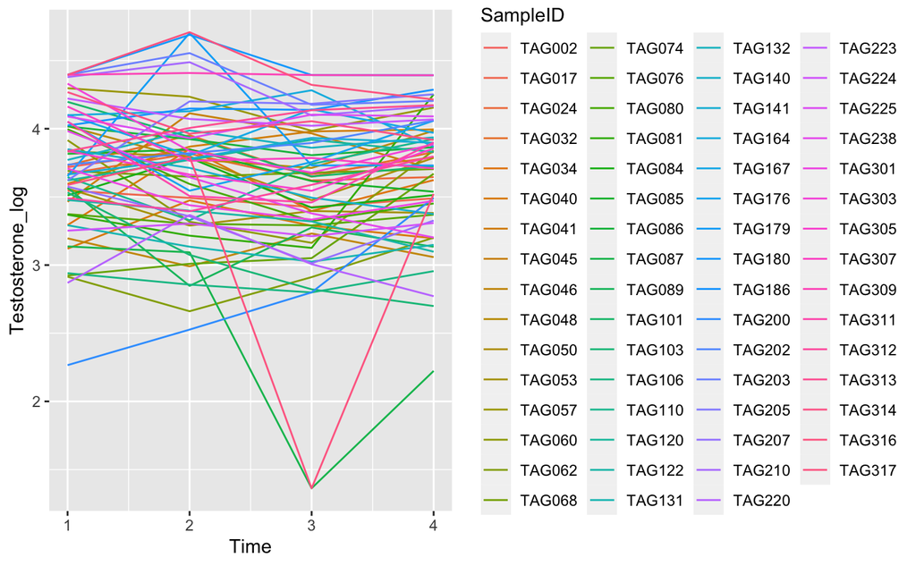

```r
All_participants_plot <- ggplot(SOS_Testosterone_final, aes(x = Time, y = Testosterone_log, group = SampleID, colour = SampleID)) +
                          geom_line()
All_participants_plot
```

```r
#Clear variables we no longer need:
rm(All_participants_plot)

# Identify where the maximum value is (T1-T4) and add as a variable to dataframe
PeakTime <- list()
PeakTime_id <- list()
Responders <- list()

for (i in unique(SOS_Testosterone_final$SampleID)) {
    idx <- which(SOS_Testosterone_final$SampleID==i, arr.ind=TRUE)
    #Get participants peak timepoint
    PeakTime[i] <- which.max(SOS_Testosterone_final$Testosterone_log[idx])
    #Get SampleID
    PeakTime_id[i] <- i
    #Using T1 > T2,T3,T4 as exclusion criteria, split group into "Responders" and "Not Responders"
      if (PeakTime[i] == "1"){
      Responders[i] <- "0"
      } else {
      Responders[i] <- "1"
      }
    }

PeakTime <- data.frame(PeakTime)
PeakTime <- t(PeakTime)
PeakTime <- data.frame(PeakTime)

PeakTime_id <- data.frame(PeakTime_id)
PeakTime_id <- t(PeakTime_id)
PeakTime_id <- data.frame(PeakTime_id)

Responders <- data.frame(Responders)
Responders <- t(Responders)
Responders <- data.frame(Responders)


Peak_time_all <- cbind(PeakTime, PeakTime_id, Responders)
#Clear variables no longer needed:
rm(PeakTime, PeakTime_id)

names(Peak_time_all)[1]<- "PeakTime"
names(Peak_time_all)[2]<- "SampleID"
names(Peak_time_all)[3]<- "Responders"

SOS_Testosterone_final <-merge(SOS_Testosterone_final, Peak_time_all, by = "SampleID", all = TRUE)
rm(Peak_time_all)
SOS_Testosterone_final$PeakTime <- as.factor(SOS_Testosterone_final$PeakTime)
```

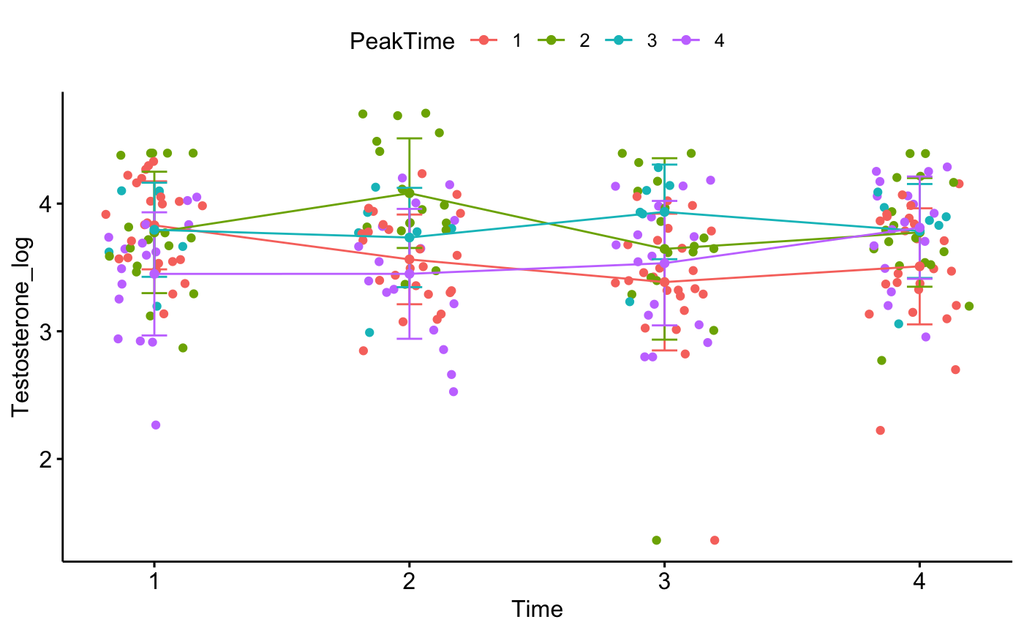

```r
Overall <- ggline(SOS_Testosterone_final, "Time", "Testosterone_log",
           group = "PeakTime",
           add = c("mean_sd", "jitter"),
           color = "PeakTime")
Overall
```

The number of subjects per “Peak Time” group:

```r
(summary(SOS_Testosterone_final$PeakTime)/4)
```

```
 1  2  3  4
24 17  6 16
```

```r
#Clear variable we no longer need:
rm(Overall)

#Divide participants by when their cortisol peak occured:
PeakTime1 <- SOS_Testosterone_final %>% filter(PeakTime == "1")
PeakTime2 <- SOS_Testosterone_final %>% filter(PeakTime == "2")
PeakTime3 <- SOS_Testosterone_final %>% filter(PeakTime == "3")
PeakTime4 <- SOS_Testosterone_final %>% filter(PeakTime == "4")
```

Now for more detail, within each “Peak time” group, we can see how individual subjects reacted:

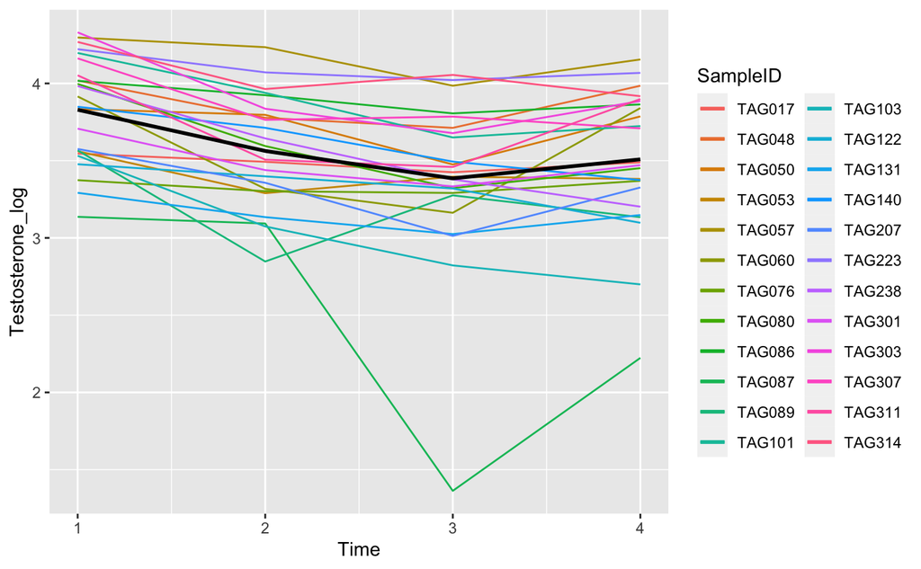

```r
PT1 <- ggplot(data = PeakTime1,aes(x = Time, y = Testosterone_log, group = SampleID, colour = SampleID)) +
       geom_line()+
       stat_summary(aes(group = 1), geom = "line", fun = mean, size = 1)

PT1
```

Descriptive stats of subjects whose response peaks at Timepoint 1

```r
summary(PeakTime1)
```

```
   SampleID              Time      Testosterone_pg_mL Testosterone_log Testosterone_nontran_win PeakTime
 Length:96          Min.   :1.00   Min.   : 1.485     Min.   :1.363    Min.   :17.17            1:96
 Class :character   1st Qu.:1.75   1st Qu.:27.813     1st Qu.:3.326    1st Qu.:27.81            2: 0
 Mode  :character   Median :2.50   Median :35.311     Median :3.564    Median :35.31            3: 0
                    Mean   :2.50   Mean   :38.713     Mean   :3.572    Mean   :39.03            4: 0
                    3rd Qu.:3.25   3rd Qu.:49.568     3rd Qu.:3.903    3rd Qu.:49.57
                    Max.   :4.00   Max.   :75.991     Max.   :4.331    Max.   :75.99
 Responders
 0:96
 1: 0
```

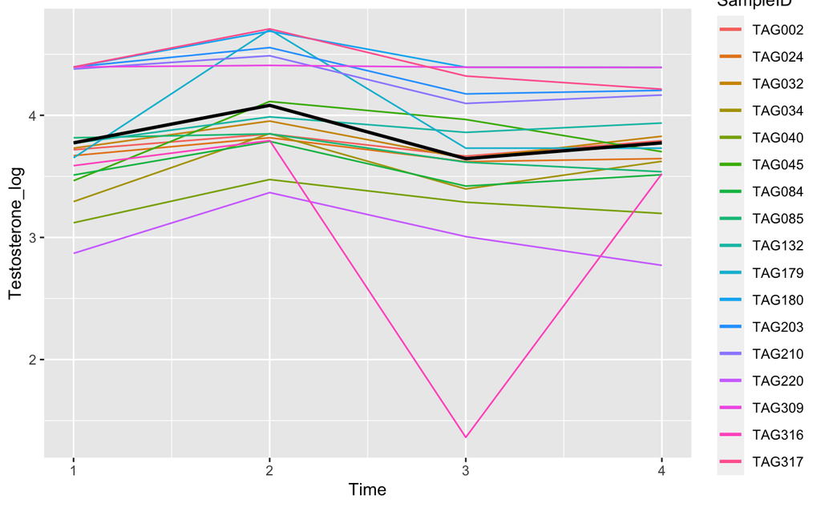

```r
PT2 <- ggplot(data = PeakTime2,aes(x = Time, y = Testosterone_log, group = SampleID, colour = SampleID)) +
      geom_line()+
      stat_summary(aes(group = 1), geom = "line", fun = mean, size = 1)
PT2
```

Descriptive stats of subjects whose response peaks at Timepoint 2

```r
summary(PeakTime2)
```

```
   SampleID              Time      Testosterone_pg_mL Testosterone_log Testosterone_nontran_win PeakTime
 Length:68          Min.   :1.00   Min.   :  1.00     Min.   :1.363    Min.   : 17.17           1: 0
 Class :character   1st Qu.:1.75   1st Qu.: 35.72     1st Qu.:3.575    1st Qu.: 35.72           2:68
 Mode  :character   Median :2.50   Median : 44.38     Median :3.793    Median : 44.38           3: 0
                    Mean   :2.50   Mean   : 54.07     Mean   :3.819    Mean   : 53.49           4: 0
                    3rd Qu.:3.25   3rd Qu.: 67.15     3rd Qu.:4.207    3rd Qu.: 67.15
                    Max.   :4.00   Max.   :163.52     Max.   :4.708    Max.   :115.71
 Responders
 0: 0
 1:68
```

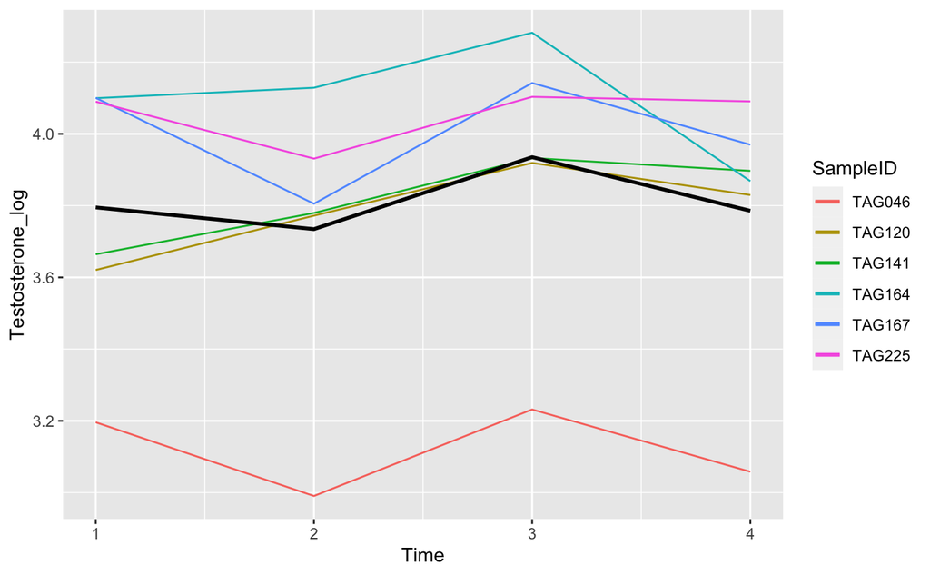

```r
PT3 <- ggplot(data = PeakTime3,aes(x = Time, y = Testosterone_log, group = SampleID, colour = SampleID)) +
      geom_line()+
     stat_summary(aes(group = 1), geom = "line", fun = mean, size = 1)
PT3
```

Descriptive stats of subjects whose response peaks at Timepoint 3

```r
summary(PeakTime3)
```

```
   SampleID              Time      Testosterone_pg_mL Testosterone_log Testosterone_nontran_win PeakTime
 Length:24          Min.   :1.00   Min.   :19.89      Min.   :2.990    Min.   :19.89            1: 0
 Class :character   1st Qu.:1.75   1st Qu.:42.36      1st Qu.:3.745    1st Qu.:42.36            2: 0
 Mode  :character   Median :2.50   Median :49.80      Median :3.908    Median :49.80            3:24
                    Mean   :2.50   Mean   :47.76      Mean   :3.813    Mean   :47.76            4: 0
                    3rd Qu.:3.25   3rd Qu.:59.91      3rd Qu.:4.093    3rd Qu.:59.91
                    Max.   :4.00   Max.   :72.39      Max.   :4.282    Max.   :72.39
 Responders
 0: 0
 1:24
```

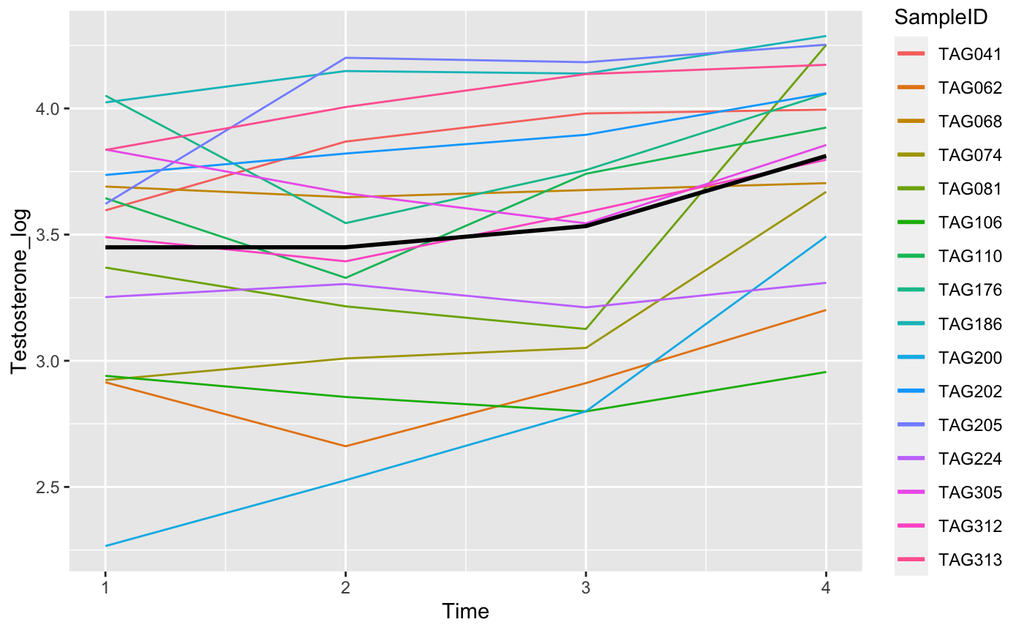

```r
PT4 <- ggplot(data = PeakTime4,aes(x = Time, y = Testosterone_log, group = SampleID, colour = SampleID)) +
        geom_line()+
        stat_summary(aes(group = 1), geom = "line", fun = mean, size = 1)
PT4
```

Descriptive stats of subjects whose response peaks at Timepoint 4

```r
summary(PeakTime4)
```

```
   SampleID              Time      Testosterone_pg_mL Testosterone_log Testosterone_nontran_win PeakTime
 Length:64          Min.   :1.00   Min.   : 8.613     Min.   :2.266    Min.   :17.15            1: 0
 Class :character   1st Qu.:1.75   1st Qu.:24.895     1st Qu.:3.215    1st Qu.:24.90            2: 0
 Mode  :character   Median :2.50   Median :38.709     Median :3.656    Median :38.71            3: 0
                    Mean   :2.50   Mean   :39.076     Mean   :3.561    Mean   :39.35            4:64
                    3rd Qu.:3.25   3rd Qu.:51.347     3rd Qu.:3.938    3rd Qu.:51.35
                    Max.   :4.00   Max.   :72.749     Max.   :4.287    Max.   :72.75
 Responders
 0: 0
 1:64
```

Some participants may be ‘non responders’, meaning they did not show a response to the task. If their peak response was at Timepoint 1, we have classified participants as ‘non responders’ (0). All other participants (who show peaks at Timepoints 2,3 or 4) are included as responders (1).

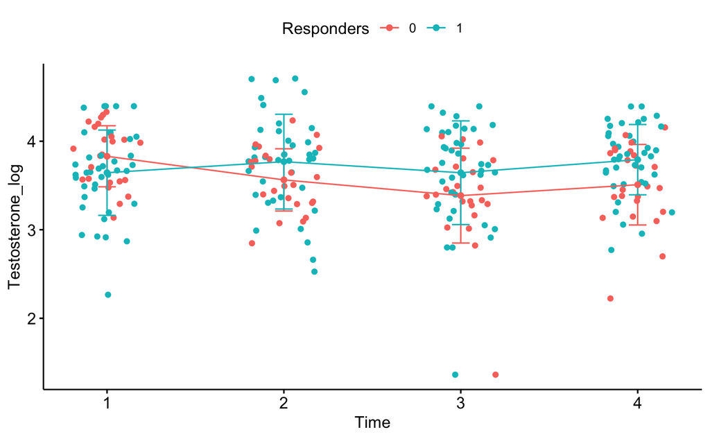

```r
#Clear variables no longer needed:
rm(PeakTime1, PT1,PeakTime2, PT2,PeakTime3, PT3, PeakTime4,PT4)

#Split group into "Responders" and "Not Responders"

RepondersvNoResponders_plot <-ggline(SOS_Testosterone_final, "Time", "Testosterone_log",
                               add = c("mean_sd", "jitter"),
                               color = "Responders")

RepondersvNoResponders_plot
```

The number of subjects Who are responders (1) and ‘non-responders’ (0)

```r
(summary(SOS_Testosterone_final$Responders)/4)
```

```
 0  1
24 39
```

```r
#Clear variable we no longer need:
rm(RepondersvNoResponders_plot)
```

We want to know whether responders (1) and ‘non-responders’ (0) showed a significantly different response at Timepoint 1:

```r
#Do a t-test to compare whether non-responders(0) had a higher T1 than responders(1)
Time_point_1 <- SOS_Testosterone_final[1:7]
Time_point_1 = Time_point_1 %>% filter(Time == "1")

compare_means(Testosterone_log ~ Responders, data = Time_point_1,
              method = "t.test")
```

| .y. | group1 | group2 | p | p.adj | p.format | p.signif | method |
| --- | --- | --- | --- | --- | --- | --- | --- |
| Testosterone_log | 0 | 1 | 0.0807768 | 0.081 | 0.081 | ns | T-test |

```r
rm(i, idx)

#For each subject, normalise time points 2,3 and 4, to timepoint 1.
Normalised_values <- list()
Normalise_id <- list()

for (i in as.character(SOS_Testosterone_final$SampleID)) {
  idx <- which(SOS_Testosterone_final$SampleID==i, arr.ind=TRUE)
  SampleID_current <- i
  baseline <- SOS_Testosterone_final$Testosterone_log[idx[1]]
    for (t in 1:4){
    Normalised_values[idx[t]] <- (SOS_Testosterone_final$Testosterone_log[idx[t]] - baseline)
    Normalise_id[idx[t]] <- SampleID_current
    }
}

#Reformat lists into data.frames
Normalised_values <- data.frame(Normalised_values)
Normalised_values <- t(Normalised_values)
Normalised_values <- data.frame(Normalised_values)

Normalise_id <- data.frame(Normalise_id)
Normalise_id <- t(Normalise_id)
Normalise_id <- data.frame(Normalise_id)
#Merge two data.frames
Normalised_all <- cbind(Normalised_values, Normalise_id)

#Clear variables no longer needed:
rm(Normalised_values, Normalise_id)

#Rename columns for merge (SampleID, also helps for checking that the rows have matched appropriately)
names(Normalised_all)[1]<- "BL_Norm_Testosterone_log"
names(Normalised_all)[2]<- "SampleID"

#Merge with SOS_Cortisol_final and remove unecessary extra SampleID column:
SOS_Testosterone_final <- cbind(SOS_Testosterone_final, Normalised_all)
SOS_Testosterone_final <- SOS_Testosterone_final[1:8]

#Clear variables no longer needed:
rm(Normalised_all, baseline, i, idx, SampleID_current, t)
```

Plot of change over time, depending on the group variable “Peak Time”:

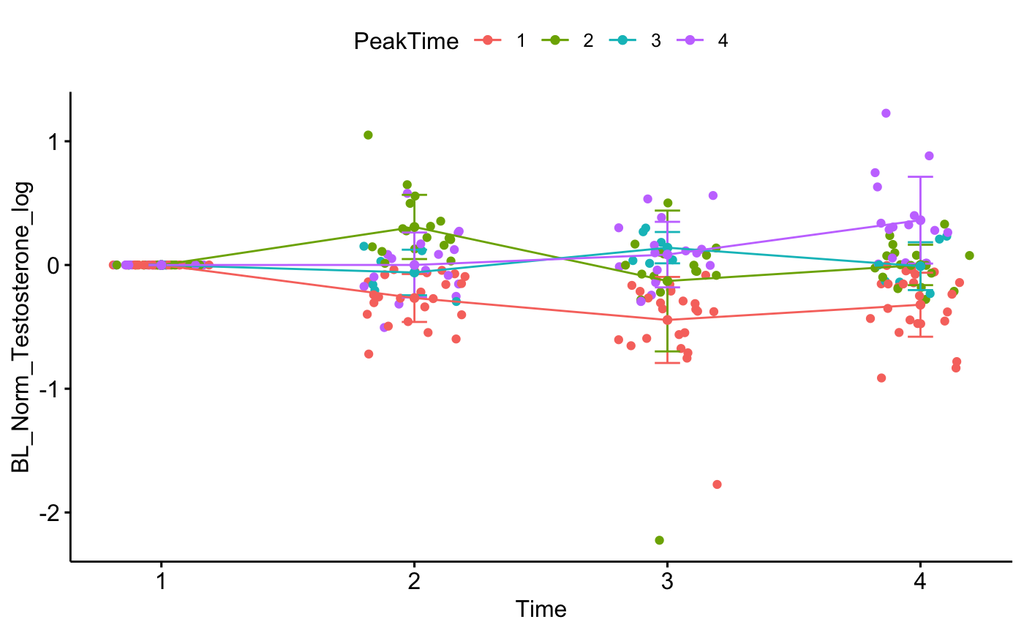

```r
Relative_to_baseline <- ggline(SOS_Testosterone_final, "Time", "BL_Norm_Testosterone_log",
           group = "PeakTime",
           add = c("mean_sd", "jitter"),
           color = "PeakTime")
Relative_to_baseline
```

Plot of change over time, depending on whether responders (1) and ‘non-responders’ (0)

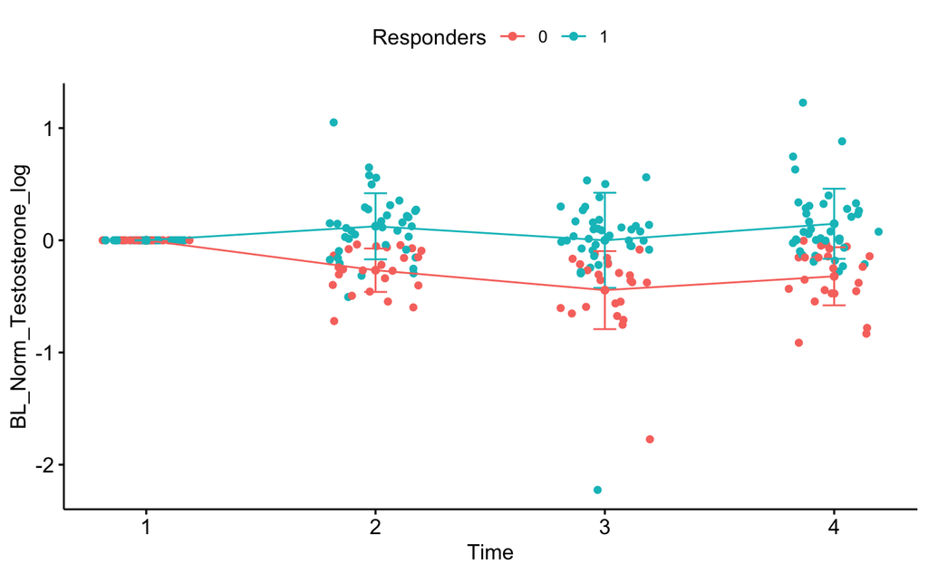

```r
Relative_to_baseline_resp <- ggline(SOS_Testosterone_final, "Time", "BL_Norm_Testosterone_log",
           group = "Responders",
           size = 0.5,
           add = c("mean_sd", "jitter"),
           color = "Responders")
Relative_to_baseline_resp
```

We want to know whether there are significant increases over time (relative to baseline)for responders (1):

```r
rm(Relative_to_baseline, Relative_to_baseline_resp)

#Do a t-test to compare whether non-responders(0) had a higher T1 than responders(1)
Responders <- SOS_Testosterone_final[1:8]
Responders = Responders %>% filter(Responders == 1)

compare_means(BL_Norm_Testosterone_log ~ Time, data = Responders,
              method = "anova")
```

| .y. | p | p.adj | p.format | p.signif | method |
| --- | --- | --- | --- | --- | --- |
| BL_Norm_Testosterone_log | 0.04875235 | 0.049 | 0.049 | * | Anova |

```r
NA
```

```r
#Follow up repeated measures t-tests
compare_means(BL_Norm_Testosterone_log ~ Time, data = Responders, paired = TRUE,
              method = "t.test")
```

| .y. | group1 | group2 | p | p.adj | p.format | p.signif | method |
| --- | --- | --- | --- | --- | --- | --- | --- |
| BL_Norm_Testosterone_log | 1 | 2 | 0.011805908 | 0.059 | 0.0118 | * | T-test |
| BL_Norm_Testosterone_log | 1 | 3 | 0.995982780 | 1.000 | 0.9960 | ns | T-test |
| BL_Norm_Testosterone_log | 1 | 4 | 0.005532209 | 0.033 | 0.0055 | ** | T-test |
| BL_Norm_Testosterone_log | 2 | 3 | 0.101999297 | 0.310 | 0.1020 | ns | T-test |
| BL_Norm_Testosterone_log | 2 | 4 | 0.731819275 | 1.000 | 0.7318 | ns | T-test |
| BL_Norm_Testosterone_log | 3 | 4 | 0.036826212 | 0.150 | 0.0368 | * | T-test |

```r
#Calculate the area under the curve for each responder:
AUC_list <- list()
AUC_id <- list()

for (i in unique(SOS_Testosterone_final$SampleID)) {
    idx <- which(SOS_Testosterone_final$SampleID==i, arr.ind=TRUE)
    #Get participants AUC for T1-4:
    AUC_list[i] <- auc(
                SOS_Testosterone_final$Time[idx],
                SOS_Testosterone_final$BL_Norm_Testosterone_log[idx],
                from = min(1, na.rm = TRUE),
                to = max(4, na.rm = TRUE),
                type = c("spline"),
                absolutearea = FALSE,
                subdivisions = 100,
                )
    #Get SampleID
    AUC_id[i] <- i
}
#Reformat lists into data.frames
AUC_list <- data.frame(AUC_list)
AUC_list <- t(AUC_list)
AUC_list <- data.frame(AUC_list)

AUC_id <- data.frame(AUC_id)
AUC_id <- t(AUC_id)
AUC_id <- data.frame(AUC_id)

#Merge two data.frames
AUC_all <- cbind(AUC_list, AUC_id)

#Clear variables no longer needed:
#rm(AUC_list, AUC_id)

#Rename columns for merge (SampleID, also helps for checking that the rows have matched appropriately)
names(AUC_all)[1]<- "AUC_BL_Norm_Testosterone_log"
names(AUC_all)[2]<- "SampleID"

#Merge with SOS_Cortisol_final and remove unecessary extra SampleID column:
SOS_Testosterone_final <-merge(SOS_Testosterone_final, AUC_all, by = "SampleID", all = TRUE)

#Clear variables no longer needed:
rm(AUC_all, i, idx)
#Update Responders dataframe to include AUC
Responders <- SOS_Testosterone_final[1:9]
Responders = Responders %>% filter(Responders == 1)
```

Plot AUC values:

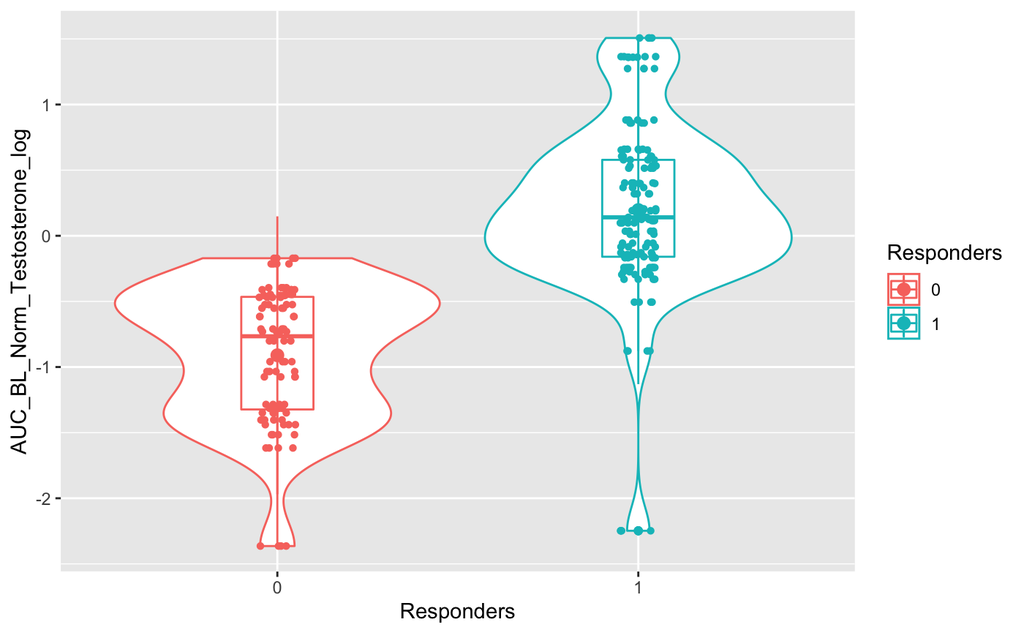

```r
#Plot AUC value for
AUC_plot <- ggplot(SOS_Testosterone_final, aes(Responders, AUC_BL_Norm_Testosterone_log, colour=Responders)) +
    geom_violin() +
    geom_boxplot(width=0.2, position = "dodge2") +
    stat_summary(fun.data=mean_sdl,
                 geom="pointrange") +
    geom_jitter(shape=16, position=position_jitter(0.05))

AUC_plot
```